# Effects of spatial separation on vowel discrimination in noise, and it’s dependence on Auditory Cortex

Version History:

- Created: 2021-09-09 Stephen Town
- Ported to notebook: 2022-05-19

```r
rm(list = ls())
suppressPackageStartupMessages( library(dplyr))
suppressPackageStartupMessages( library(tidyverse))
suppressPackageStartupMessages( library(lme4))
suppressPackageStartupMessages( library(DHARMa))
suppressPackageStartupMessages( library(scales))
suppressPackageStartupMessages( library(sjPlot))
```

## 1. Load Data

From animals with functional cooling loops (F1311 and F1509) and animals tested with behavior only (F1201, F1203, F1216, F1217).

```r
data_path = '/home/stephen/Github/Vowel_Discrimination_In_Noise/Results/Vowels_Unmasking/data/analysis'

floz = read_csv( file.path( data_path, 'F1201.csv'), show_col_types = FALSE)
virg = read_csv( file.path( data_path, 'F1203.csv'), show_col_types = FALSE)
mini = read_csv( file.path( data_path, 'F1216.csv'), show_col_types = FALSE)
clio = read_csv( file.path( data_path, 'F1217.csv'), show_col_types = FALSE)
magnum = read_csv( file.path( data_path, 'F1311.csv'), show_col_types = FALSE)
robin  = read_csv( file.path( data_path, 'F1509.csv'), show_col_types = FALSE)

cols = c('fNum','treatment',"VowelLocation","SpatialCondition","Atten","F1","Correct")
df = rbind(magnum[cols], robin[cols], floz[cols], virg[cols], mini[cols], clio[cols])

rm(list = c("clio", "floz", "virg", "mini", "robin", "magnum"))
head(df)
```

| fNum | treatment | VowelLocation | SpatialCondition | Atten | F1 | Correct |
| --- | --- | --- | --- | --- | --- | --- |
| 1311 | FALSE | left | separated | -6 | 936 | 1 |
| 1311 | FALSE | right | separated | -6 | 437 | 0 |
| 1311 | FALSE | left | separated | -12 | 437 | 0 |
| 1311 | FALSE | left | colocated | -12 | 437 | 1 |
| 1311 | FALSE | left | colocated | -9 | 936 | 1 |
| 1311 | FALSE | left | separated | -15 | 936 | 1 |

```r
table(df$fNum)
```

```
1201 1203 1216 1217 1311 1509
3112 2501 2821 2335 2744 1430
```

```r
nrow(df)
```

```
[1] 14943
```

## 2. Transform data

Format subject number as factor and convert binary data to counts.

```r
df$fNum <- as.factor(df$fNum)
df$F1 <- as.factor(df$F1)    # First formant = vowel identity

df$vowel_level_orig = 57 - df$Atten
df$vowel_level <- rescale(df$vowel_level_orig)

counts = df %>%
  group_by(fNum, treatment, VowelLocation, SpatialCondition, F1, vowel_level) %>%
  summarise(
    nCorrect = sum(Correct),
    nTotal = n(),
    .groups = 'keep'
    ) %>%
  mutate( pCorrect = nCorrect / nTotal * 100)

head(counts)
```

| fNum | treatment | VowelLocation | SpatialCondition | F1 | vowel_level | nCorrect | nTotal | pCorrect |
| --- | --- | --- | --- | --- | --- | --- | --- | --- |
| 1201 | FALSE | left | colocated | 460 | 0.0 | 91 | 132 | 68.93939 |
| 1201 | FALSE | left | colocated | 460 | 0.4 | 15 | 19 | 78.94737 |
| 1201 | FALSE | left | colocated | 460 | 0.6 | 80 | 119 | 67.22689 |
| 1201 | FALSE | left | colocated | 730 | 0.0 | 49 | 138 | 35.50725 |
| 1201 | FALSE | left | colocated | 730 | 0.4 | 8 | 18 | 44.44444 |
| 1201 | FALSE | left | colocated | 730 | 0.6 | 68 | 121 | 56.19835 |

## 7. All In One Model

What if we just included everything in the dataset, rather than doing four separate modelling analyses?

[output not shown]

Split data for later testing

```r
control_behav = ACS_extended %>%
  filter(treatment == FALSE)


cooled_animals = ACS_extended %>%
  filter(fNum == 1311 | fNum == 1509)

nrow(cooled_animals)
```

```
[1] 192
```

### 7.1. Model Fitting

Start with just the main effects

```r
ACS_mdl_1 <- glmer(
  cbind(nCorrect, nTotal - nCorrect) ~ SpatialCondition.x + treatment + vowel_level + VowelLocation + (1|fNum) + (0+clean_pCorrect|fNum),
  data = ACS_extended,
  family = binomial)

summary(ACS_mdl_1)
```

```
Generalized linear mixed model fit by maximum likelihood (Laplace Approximation) ['glmerMod']
 Family: binomial  ( logit )
Formula: cbind(nCorrect, nTotal - nCorrect) ~ SpatialCondition.x + treatment +
    vowel_level + VowelLocation + (1 | fNum) + (0 + clean_pCorrect |      fNum)
   Data: ACS_extended

     AIC      BIC   logLik deviance df.resid
  1717.3   1743.7   -851.7   1703.3      313

Scaled residuals:
    Min      1Q  Median      3Q     Max
-5.1272 -0.9766  0.0810  0.9806  3.6507

Random effects:
 Groups Name           Variance Std.Dev.
 fNum   (Intercept)     3.016   1.737
 fNum.1 clean_pCorrect 12.082   3.476
Number of obs: 320, groups:  fNum, 6

Fixed effects:
                            Estimate Std. Error z value Pr(>|z|)
(Intercept)                 -1.65258    0.72551  -2.278 0.022738 *
SpatialCondition.xseparated  0.14226    0.04321   3.292 0.000995 ***
treatmentTRUE               -0.25715    0.10320  -2.492 0.012710 *
vowel_level                  0.19638    0.08794   2.233 0.025538 *
VowelLocationright          -0.06120    0.04391  -1.394 0.163405
---
Signif. codes:  0 ‘***’ 0.001 ‘**’ 0.01 ‘*’ 0.05 ‘.’ 0.1 ‘ ’ 1

Correlation of Fixed Effects:
            (Intr) SptlC. trTRUE vwl_lv
SptlCndtn.x -0.032
tretmntTRUE -0.022 -0.007
vowel_level -0.029 -0.003  0.008
VwlLctnrght -0.039  0.001  0.010 -0.009
```

Next, add an interaction between spatial condition and treatment

```r
ACS_mdl_2 <- glmer(
  cbind(nCorrect, nTotal - nCorrect) ~ SpatialCondition.x*treatment + vowel_level + VowelLocation + (1|fNum) + (0+clean_pCorrect|fNum),
  data = ACS_extended,
  family = binomial)

summary(ACS_mdl_2)
```

```
Generalized linear mixed model fit by maximum likelihood (Laplace Approximation) ['glmerMod']
 Family: binomial  ( logit )
Formula: cbind(nCorrect, nTotal - nCorrect) ~ SpatialCondition.x * treatment +
    vowel_level + VowelLocation + (1 | fNum) + (0 + clean_pCorrect |      fNum)
   Data: ACS_extended

     AIC      BIC   logLik deviance df.resid
  1716.9   1747.1   -850.5   1700.9      312

Scaled residuals:
    Min      1Q  Median      3Q     Max
-4.8272 -0.8993  0.0856  0.9953  3.6070

Random effects:
 Groups Name           Variance Std.Dev.
 fNum   (Intercept)     3.025   1.739
 fNum.1 clean_pCorrect 12.087   3.477
Number of obs: 320, groups:  fNum, 6

Fixed effects:
                                          Estimate Std. Error z value Pr(>|z|)
(Intercept)                               -1.64229    0.72651  -2.261  0.02379 *
SpatialCondition.xseparated                0.12414    0.04477   2.773  0.00556 **
treatmentTRUE                             -0.38603    0.13213  -2.921  0.00348 **
vowel_level                                0.19629    0.08795   2.232  0.02562 *
VowelLocationright                        -0.06126    0.04392  -1.395  0.16303
SpatialCondition.xseparated:treatmentTRUE  0.26522    0.17166   1.545  0.12234
---
Signif. codes:  0 ‘***’ 0.001 ‘**’ 0.01 ‘*’ 0.05 ‘.’ 0.1 ‘ ’ 1

Correlation of Fixed Effects:
            (Intr) SptlC. trTRUE vwl_lv VwlLct
SptlCndtn.x -0.033
tretmntTRUE -0.023  0.162
vowel_level -0.029 -0.003  0.007
VwlLctnrght -0.039  0.001  0.008 -0.009
SptlC.:TRUE  0.009 -0.261 -0.622 -0.001 -0.001
```

Add in the interaction between treatment and Attenuation that might capture greater effects of cooling for quieter sounds

```r
ACS_mdl_3 <- glmer(
  cbind(nCorrect, nTotal - nCorrect) ~ SpatialCondition.x*treatment + treatment*vowel_level + VowelLocation + (1|fNum) + (0+clean_pCorrect|fNum),
  data = ACS_extended,
  family = binomial)

summary(ACS_mdl_3)
```

```
Generalized linear mixed model fit by maximum likelihood (Laplace Approximation) ['glmerMod']
 Family: binomial  ( logit )
Formula: cbind(nCorrect, nTotal - nCorrect) ~ SpatialCondition.x * treatment +
    treatment * vowel_level + VowelLocation + (1 | fNum) + (0 +      clean_pCorrect | fNum)
   Data: ACS_extended

     AIC      BIC   logLik deviance df.resid
  1718.9   1752.8   -850.5   1700.9      311

Scaled residuals:
    Min      1Q  Median      3Q     Max
-4.8458 -0.9006  0.0836  0.9947  3.6036

Random effects:
 Groups Name           Variance Std.Dev.
 fNum   (Intercept)     3.03    1.741
 fNum.1 clean_pCorrect 12.09    3.477
Number of obs: 320, groups:  fNum, 6

Fixed effects:
                                          Estimate Std. Error z value Pr(>|z|)
(Intercept)                               -1.64148    0.72715  -2.257  0.02398 *
SpatialCondition.xseparated                0.12415    0.04477   2.773  0.00555 **
treatmentTRUE                             -0.40961    0.25288  -1.620  0.10527
vowel_level                                0.19446    0.08953   2.172  0.02986 *
VowelLocationright                        -0.06126    0.04392  -1.395  0.16308
SpatialCondition.xseparated:treatmentTRUE  0.26506    0.17170   1.544  0.12265
treatmentTRUE:vowel_level                  0.03676    0.33601   0.109  0.91289
---
Signif. codes:  0 ‘***’ 0.001 ‘**’ 0.01 ‘*’ 0.05 ‘.’ 0.1 ‘ ’ 1

Correlation of Fixed Effects:
            (Intr) SptlC. trTRUE vwl_lv VwlLct SC.:TR
SptlCndtn.x -0.033
tretmntTRUE -0.021  0.083
vowel_level -0.030 -0.003  0.163
VwlLctnrght -0.039  0.001  0.003 -0.010
SptlC.:TRUE  0.009 -0.261 -0.318  0.001 -0.001
trtmnTRUE:_  0.010  0.002 -0.853 -0.187  0.001 -0.008
```

Finally, consider a three-way interaction between cooling, spatial separation and sound level

```r
ACS_mdl_4 <- glmer(
  cbind(nCorrect, nTotal - nCorrect) ~ SpatialCondition.x*treatment*vowel_level + VowelLocation + (1|fNum) + (0+clean_pCorrect|fNum),
  data = ACS_extended,
  family = binomial)

summary(ACS_mdl_4)
```

```
Generalized linear mixed model fit by maximum likelihood (Laplace Approximation) ['glmerMod']
 Family: binomial  ( logit )
Formula: cbind(nCorrect, nTotal - nCorrect) ~ SpatialCondition.x * treatment *
    vowel_level + VowelLocation + (1 | fNum) + (0 + clean_pCorrect |      fNum)
   Data: ACS_extended

     AIC      BIC   logLik deviance df.resid
  1722.4   1763.9   -850.2   1700.4      309

Scaled residuals:
    Min      1Q  Median      3Q     Max
-4.7540 -0.8927  0.0881  0.9980  3.6965

Random effects:
 Groups Name           Variance Std.Dev.
 fNum   (Intercept)     3.029   1.740
 fNum.1 clean_pCorrect 12.101   3.479
Number of obs: 320, groups:  fNum, 6

Fixed effects:
                                                      Estimate Std. Error z value Pr(>|z|)
(Intercept)                                           -1.66184    0.72795  -2.283   0.0224 *
SpatialCondition.xseparated                            0.16253    0.08580   1.894   0.0582 .
treatmentTRUE                                         -0.30803    0.31220  -0.987   0.3238
vowel_level                                            0.22564    0.10745   2.100   0.0357 *
VowelLocationright                                    -0.06128    0.04392  -1.395   0.1629
SpatialCondition.xseparated:treatmentTRUE              0.05196    0.42021   0.124   0.9016
SpatialCondition.xseparated:vowel_level               -0.06392    0.12189  -0.524   0.6000
treatmentTRUE:vowel_level                             -0.13204    0.45228  -0.292   0.7703
SpatialCondition.xseparated:treatmentTRUE:vowel_level  0.35317    0.63554   0.556   0.5784
---
Signif. codes:  0 ‘***’ 0.001 ‘**’ 0.01 ‘*’ 0.05 ‘.’ 0.1 ‘ ’ 1

Correlation of Fixed Effects:
            (Intr) SptlC. trTRUE vwl_lv VwlLct SpC.:TRUE SpC.:_ tTRUE:
SptlCndtn.x -0.061
tretmntTRUE -0.024  0.131
vowel_level -0.053  0.469  0.172
VwlLctnrght -0.039  0.001  0.002 -0.008
SptlC.:TRUE  0.015 -0.204 -0.642 -0.096  0.001
SptlCndt.:_  0.051 -0.853 -0.112 -0.553  0.000  0.174
trtmnTRUE:_  0.016 -0.110 -0.906 -0.188  0.002  0.611     0.130
SpC.:TRUE:_ -0.013  0.164  0.586  0.106 -0.001 -0.913    -0.192 -0.670
```

Repeat model 2, but without the random slope

```r
ACS_mdl_5 <- glmer(
  cbind(nCorrect, nTotal - nCorrect) ~ SpatialCondition.x*treatment + vowel_level + VowelLocation + (1|fNum),
  data = ACS_extended,
  family = binomial)

summary(ACS_mdl_5)
```

```
Generalized linear mixed model fit by maximum likelihood (Laplace Approximation) ['glmerMod']
 Family: binomial  ( logit )
Formula: cbind(nCorrect, nTotal - nCorrect) ~ SpatialCondition.x * treatment +
    vowel_level + VowelLocation + (1 | fNum)
   Data: ACS_extended

     AIC      BIC   logLik deviance df.resid
  2197.4   2223.7  -1091.7   2183.4      313

Scaled residuals:
    Min      1Q  Median      3Q     Max
-6.0358 -1.0387  0.0826  1.0923  6.3120

Random effects:
 Groups Name        Variance Std.Dev.
 fNum   (Intercept) 0.02439  0.1562
Number of obs: 320, groups:  fNum, 6

Fixed effects:
                                          Estimate Std. Error z value Pr(>|z|)
(Intercept)                                0.17346    0.08723   1.989  0.04675 *
SpatialCondition.xseparated                0.11387    0.04352   2.616  0.00889 **
treatmentTRUE                             -0.32224    0.12621  -2.553  0.01067 *
vowel_level                                0.74024    0.07829   9.456  < 2e-16 ***
VowelLocationright                        -0.03140    0.04202  -0.747  0.45490
SpatialCondition.xseparated:treatmentTRUE  0.26011    0.16738   1.554  0.12018
---
Signif. codes:  0 ‘***’ 0.001 ‘**’ 0.01 ‘*’ 0.05 ‘.’ 0.1 ‘ ’ 1

Correlation of Fixed Effects:
            (Intr) SptlC. trTRUE vwl_lv VwlLct
SptlCndtn.x -0.245
tretmntTRUE -0.119  0.166
vowel_level -0.523  0.001 -0.011
VwlLctnrght -0.238  0.002 -0.002 -0.007
SptlC.:TRUE  0.064 -0.260 -0.633  0.001 -0.001
```

What about clean performance as a covariate

```r
ACS_mdl_6 <- glmer(
  cbind(nCorrect, nTotal - nCorrect) ~ SpatialCondition.x*treatment + vowel_level + VowelLocation + clean_pCorrect + (1|fNum),
  data = ACS_extended,
  family = binomial)

summary(ACS_mdl_6)
```

```
Generalized linear mixed model fit by maximum likelihood (Laplace Approximation) ['glmerMod']
 Family: binomial  ( logit )
Formula: cbind(nCorrect, nTotal - nCorrect) ~ SpatialCondition.x * treatment +
    vowel_level + VowelLocation + clean_pCorrect + (1 | fNum)
   Data: ACS_extended

     AIC      BIC   logLik deviance df.resid
  1811.5   1841.6   -897.7   1795.5      312

Scaled residuals:
    Min      1Q  Median      3Q     Max
-4.9620 -0.9822  0.1119  1.0835  4.0623

Random effects:
 Groups Name        Variance Std.Dev.
 fNum   (Intercept) 0.01942  0.1394
Number of obs: 320, groups:  fNum, 6

Fixed effects:
                                          Estimate Std. Error z value Pr(>|z|)
(Intercept)                               -2.13410    0.14545 -14.673  < 2e-16 ***
SpatialCondition.xseparated                0.12310    0.04434   2.776   0.0055 **
treatmentTRUE                             -0.26652    0.13144  -2.028   0.0426 *
vowel_level                                0.37099    0.08159   4.547 5.44e-06 ***
VowelLocationright                        -0.01855    0.04288  -0.433   0.6653
clean_pCorrect                             3.19915    0.16692  19.166  < 2e-16 ***
SpatialCondition.xseparated:treatmentTRUE  0.27177    0.17419   1.560   0.1187
---
Signif. codes:  0 ‘***’ 0.001 ‘**’ 0.01 ‘*’ 0.05 ‘.’ 0.1 ‘ ’ 1

Correlation of Fixed Effects:
            (Intr) SptlC. trTRUE vwl_lv VwlLct cln_pC
SptlCndtn.x -0.163
tretmntTRUE -0.092  0.163
vowel_level -0.117 -0.002  0.024
VwlLctnrght -0.156  0.003  0.001 -0.008
clen_pCrrct -0.818  0.016  0.009 -0.244  0.010
SptlC.:TRUE  0.029 -0.254 -0.633 -0.005 -0.003  0.012
```

```r
ACS_mdl_7 <- glmer(
  cbind(nCorrect, nTotal - nCorrect) ~ SpatialCondition.x*treatment + vowel_level + VowelLocation + (1|fNum) + (1|clean_pCorrect),
  data = ACS_extended,
  family = binomial)

summary(ACS_mdl_7)
```

```
Generalized linear mixed model fit by maximum likelihood (Laplace Approximation) ['glmerMod']
 Family: binomial  ( logit )
Formula: cbind(nCorrect, nTotal - nCorrect) ~ SpatialCondition.x * treatment +
    vowel_level + VowelLocation + (1 | fNum) + (1 | clean_pCorrect)
   Data: ACS_extended

     AIC      BIC   logLik deviance df.resid
  1610.0   1640.1   -797.0   1594.0      312

Scaled residuals:
    Min      1Q  Median      3Q     Max
-4.7490 -0.6426  0.0737  0.6734  2.7290

Random effects:
 Groups         Name        Variance Std.Dev.
 clean_pCorrect (Intercept) 0.35248  0.5937
 fNum           (Intercept) 0.01105  0.1051
Number of obs: 320, groups:  clean_pCorrect, 85; fNum, 6

Fixed effects:
                                          Estimate Std. Error z value Pr(>|z|)
(Intercept)                                0.23431    0.14013   1.672 0.094508 .
SpatialCondition.xseparated                0.12763    0.04527   2.819 0.004814 **
treatmentTRUE                             -0.31542    0.15442  -2.043 0.041092 *
vowel_level                                0.65877    0.17530   3.758 0.000171 ***
VowelLocationright                         0.09345    0.08855   1.055 0.291253
SpatialCondition.xseparated:treatmentTRUE  0.26439    0.16980   1.557 0.119462
---
Signif. codes:  0 ‘***’ 0.001 ‘**’ 0.01 ‘*’ 0.05 ‘.’ 0.1 ‘ ’ 1

Correlation of Fixed Effects:
            (Intr) SptlC. trTRUE vwl_lv VwlLct
SptlCndtn.x -0.156
tretmntTRUE -0.014  0.141
vowel_level -0.712 -0.001 -0.147
VwlLctnrght -0.306 -0.001  0.035 -0.019
SptlC.:TRUE  0.044 -0.267 -0.526 -0.001  0.002
```

```r
ACS_mdl_8 <- glmer(
  cbind(nCorrect, nTotal - nCorrect) ~ SpatialCondition.x*treatment + vowel_level + VowelLocation + (1|fNum),
  data = ACS_extended,
  family = binomial)

summary(ACS_mdl_8)
```

```
Generalized linear mixed model fit by maximum likelihood (Laplace Approximation) ['glmerMod']
 Family: binomial  ( logit )
Formula: cbind(nCorrect, nTotal - nCorrect) ~ SpatialCondition.x * treatment +
    vowel_level + VowelLocation + (1 | fNum)
   Data: ACS_extended

     AIC      BIC   logLik deviance df.resid
  2197.4   2223.7  -1091.7   2183.4      313

Scaled residuals:
    Min      1Q  Median      3Q     Max
-6.0358 -1.0387  0.0826  1.0923  6.3120

Random effects:
 Groups Name        Variance Std.Dev.
 fNum   (Intercept) 0.02439  0.1562
Number of obs: 320, groups:  fNum, 6

Fixed effects:
                                          Estimate Std. Error z value Pr(>|z|)
(Intercept)                                0.17346    0.08723   1.989  0.04675 *
SpatialCondition.xseparated                0.11387    0.04352   2.616  0.00889 **
treatmentTRUE                             -0.32224    0.12621  -2.553  0.01067 *
vowel_level                                0.74024    0.07829   9.456  < 2e-16 ***
VowelLocationright                        -0.03140    0.04202  -0.747  0.45490
SpatialCondition.xseparated:treatmentTRUE  0.26011    0.16738   1.554  0.12018
---
Signif. codes:  0 ‘***’ 0.001 ‘**’ 0.01 ‘*’ 0.05 ‘.’ 0.1 ‘ ’ 1

Correlation of Fixed Effects:
            (Intr) SptlC. trTRUE vwl_lv VwlLct
SptlCndtn.x -0.245
tretmntTRUE -0.119  0.166
vowel_level -0.523  0.001 -0.011
VwlLctnrght -0.238  0.002 -0.002 -0.007
SptlC.:TRUE  0.064 -0.260 -0.633  0.001 -0.001
```

```r
tab_model(ACS_mdl_8)
```

[output not shown]

### 7.2. Model Selection

AIC values

```r
anova(ACS_mdl_1, ACS_mdl_2, ACS_mdl_3, ACS_mdl_4)
```

```
Data: ACS_extended
Models:
ACS_mdl_1: cbind(nCorrect, nTotal - nCorrect) ~ SpatialCondition.x + treatment + vowel_level + VowelLocation + (1 | fNum) + (0 + clean_pCorrect | fNum)
ACS_mdl_2: cbind(nCorrect, nTotal - nCorrect) ~ SpatialCondition.x * treatment + vowel_level + VowelLocation + (1 | fNum) + (0 + clean_pCorrect | fNum)
ACS_mdl_3: cbind(nCorrect, nTotal - nCorrect) ~ SpatialCondition.x * treatment + treatment * vowel_level + VowelLocation + (1 | fNum) + (0 + clean_pCorrect | fNum)
ACS_mdl_4: cbind(nCorrect, nTotal - nCorrect) ~ SpatialCondition.x * treatment * vowel_level + VowelLocation + (1 | fNum) + (0 + clean_pCorrect | fNum)
          npar    AIC    BIC  logLik deviance  Chisq Df Pr(>Chisq)
ACS_mdl_1    7 1717.3 1743.7 -851.65   1703.3
ACS_mdl_2    8 1716.9 1747.1 -850.46   1700.9 2.3946  1     0.1218
ACS_mdl_3    9 1718.9 1752.8 -850.45   1700.9 0.0120  1     0.9129
ACS_mdl_4   11 1722.4 1763.9 -850.21   1700.4 0.4899  2     0.7827
```

Compare models with same fixed effects, but varying in random effect design

```r
anova(ACS_mdl_2, ACS_mdl_6, ACS_mdl_7, ACS_mdl_8)
```

```
Data: ACS_extended
Models:
ACS_mdl_8: cbind(nCorrect, nTotal - nCorrect) ~ SpatialCondition.x * treatment + vowel_level + VowelLocation + (1 | fNum)
ACS_mdl_2: cbind(nCorrect, nTotal - nCorrect) ~ SpatialCondition.x * treatment + vowel_level + VowelLocation + (1 | fNum) + (0 + clean_pCorrect | fNum)
ACS_mdl_6: cbind(nCorrect, nTotal - nCorrect) ~ SpatialCondition.x * treatment + vowel_level + VowelLocation + clean_pCorrect + (1 | fNum)
ACS_mdl_7: cbind(nCorrect, nTotal - nCorrect) ~ SpatialCondition.x * treatment + vowel_level + VowelLocation + (1 | fNum) + (1 | clean_pCorrect)
          npar    AIC    BIC   logLik deviance  Chisq Df Pr(>Chisq)
ACS_mdl_8    7 2197.4 2223.7 -1091.68   2183.4
ACS_mdl_2    8 1716.9 1747.1  -850.46   1700.9 482.45  1  < 2.2e-16 ***
ACS_mdl_6    8 1811.5 1841.6  -897.73   1795.5   0.00  0
ACS_mdl_7    8 1610.0 1640.1  -797.00   1594.0 201.46  0
---
Signif. codes:  0 ‘***’ 0.001 ‘**’ 0.01 ‘*’ 0.05 ‘.’ 0.1 ‘ ’ 1
```

### 7.3. Model Prediction

```r
ACS_extended$fit <- predict(ACS_mdl_8, ACS_extended, type="response")


# Summarize performance for ferret, stimulus condition, treatment, and sound level
ACS_agg_by_level <- ACS_extended %>%
  mutate(
    predicted_correct = fit * nTotal
    ) %>%
  group_by(
    fNum, SpatialCondition.x, treatment, vowel_level,
    ) %>%
  summarise(
    nCorrect = sum(nCorrect),
    nTotal = sum(nTotal),
    predicted_correct = sum(predicted_correct),
    .groups = 'keep'
    ) %>%
  mutate(
    pCorrect = nCorrect / nTotal * 100,
    fit_p = predicted_correct / nTotal * 100,
    group = interaction(fNum, treatment)
  )

# Restore original vowel levels for plotting
ACS_agg_by_level$vowel_level <- rescale(
  ACS_agg_by_level$vowel_level,
  to = c(min(df$vowel_level_orig) , max(df$vowel_level_orig)))

# Calculate SNR
ACS_agg_by_level$SNR = ACS_agg_by_level$vowel_level - 67
```

Plot

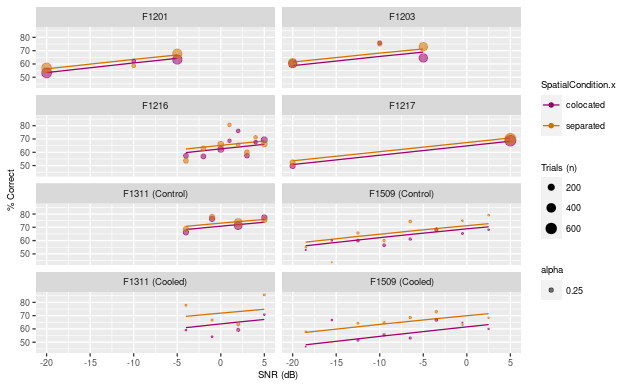

```r
ggplot(
  ACS_agg_by_level,
  aes(x = SNR, color = SpatialCondition.x)
  ) +
geom_line(
  aes(y = fit_p)
  ) +
geom_point(
  shape = 19,
  aes(
    y = pCorrect,
    size = nTotal,
    alpha = 0.25
    )
  ) +
scale_size(range = c(0, 4))+
scale_color_manual(values=c('#9e0067','#d37000')) +
labs(
  x = "SNR (dB)",
  y = "% Correct",
  size='Trials (n)') +
theme(
  axis.text = element_text(size = 7.5),
  axis.title = element_text(size = 8),
  strip.text = element_text(size = 8),
  legend.title = element_text(size=8),
  legend.text = element_text(size=7.5)
  #strip.background = element_rect(colour="black", fill="white")
  ) +
facet_wrap(
  . ~ group,
  ncol = 2,
  labeller = labeller(group =
    c("1201.FALSE" = "F1201",
      "1203.FALSE" = "F1203",
      "1216.FALSE" = "F1216",
      "1217.FALSE" = "F1217",
      "1311.FALSE" = "F1311 (Control)",
      "1509.FALSE" = "F1509 (Control)",
      "1311.TRUE" = "F1311 (Cooled)",
      "1509.TRUE" = "F1509 (Cooled)")
  )
)

ggsave(filename = "Unmasking_ACS8_predictions.png", width = 11.2, height = 11.5, units = "cm", dpi=300)
```

```r
# Summarize performance for ferret, stimulus condition, treatment
ACS_agg_over_level <- ACS_extended %>%
  mutate(
    predicted_correct = fit * nTotal
    ) %>%
  group_by(
    fNum, SpatialCondition.x, treatment,
    ) %>%
  summarise(
    nCorrect = sum(nCorrect),
    nTotal = sum(nTotal),
    predicted_correct = sum(predicted_correct),
    .groups = 'keep'
    ) %>%
  mutate(
    pCorrect = nCorrect / nTotal * 100,
    fit_p = predicted_correct / nTotal * 100
  )
```

```r
pt = pivot_longer(
      ACS_agg_over_level,
      -c(fNum, SpatialCondition.x, treatment, nTotal, nCorrect, predicted_correct),
      names_to='metric',
      values_to = 'values')

pt = pt %>% select(fNum, SpatialCondition.x, treatment, metric, values)

pt = pivot_wider(pt,
    names_from = SpatialCondition.x,
    values_from = values
  )


ggplot(pt,
    aes(x = colocated, y = separated, color=fNum)
    ) +
geom_point() +
facet_grid(metric ~ treatment)
```

[output not shown]

### 7.4. Model Checking

```r
simulationOutput <- simulateResiduals(fittedModel = ACS_mdl_7, n=500, plot = T)
```

[output not shown]

# 8. Running models on subsets of the data to confirm main findings

## 8.1. Control data without cooling - do we still see an effect of spatial unmasking

```r
control_model <- glmer(
  cbind(nCorrect, nTotal - nCorrect) ~ SpatialCondition.x + vowel_level + VowelLocation + (1|fNum),
  data = control_behav,
  family = binomial)

summary(control_model)
```

```
Generalized linear mixed model fit by maximum likelihood (Laplace Approximation) ['glmerMod']
 Family: binomial  ( logit )
Formula: cbind(nCorrect, nTotal - nCorrect) ~ SpatialCondition.x + vowel_level +
    VowelLocation + (1 | fNum)
   Data: control_behav

     AIC      BIC   logLik deviance df.resid
  1814.0   1831.1   -902.0   1804.0      219

Scaled residuals:
    Min      1Q  Median      3Q     Max
-5.9559 -1.1336  0.0456  1.2773  6.4025

Random effects:
 Groups Name        Variance Std.Dev.
 fNum   (Intercept) 0.0258   0.1606
Number of obs: 224, groups:  fNum, 6

Fixed effects:
                            Estimate Std. Error z value Pr(>|z|)
(Intercept)                  0.18002    0.08938   2.014    0.044 *
SpatialCondition.xseparated  0.11373    0.04354   2.612    0.009 **
vowel_level                  0.74647    0.07978   9.357   <2e-16 ***
VowelLocationright          -0.05916    0.04353  -1.359    0.174
---
Signif. codes:  0 ‘***’ 0.001 ‘**’ 0.01 ‘*’ 0.05 ‘.’ 0.1 ‘ ’ 1

Correlation of Fixed Effects:
            (Intr) SptlC. vwl_lv
SptlCndtn.x -0.239
vowel_level -0.523  0.001
VwlLctnrght -0.241  0.002 -0.009
```

## 8.2. Effect of cooling with just animals tested with cooling

```r
cool_model <- glmer(
  cbind(nCorrect, nTotal - nCorrect) ~ SpatialCondition.x*treatment + vowel_level + VowelLocation + (1|fNum),
  data = cooled_animals,
  family = binomial)
```

```
boundary (singular) fit: see help('isSingular')
```

```r
summary(cool_model)
```

```
Generalized linear mixed model fit by maximum likelihood (Laplace Approximation) ['glmerMod']
 Family: binomial  ( logit )
Formula: cbind(nCorrect, nTotal - nCorrect) ~ SpatialCondition.x * treatment +
    vowel_level + VowelLocation + (1 | fNum)
   Data: cooled_animals

     AIC      BIC   logLik deviance df.resid
   861.9    884.7   -423.9    847.9      185

Scaled residuals:
    Min      1Q  Median      3Q     Max
-5.1783 -0.8710 -0.0057  0.8517  3.8636

Random effects:
 Groups Name        Variance Std.Dev.
 fNum   (Intercept) 0        0
Number of obs: 192, groups:  fNum, 2

Fixed effects:
                                          Estimate Std. Error z value Pr(>|z|)
(Intercept)                                0.10659    0.15328   0.695  0.48679
SpatialCondition.xseparated                0.11295    0.09741   1.160  0.24623
treatmentTRUE                             -0.35079    0.13257  -2.646  0.00814 **
vowel_level                                0.93760    0.17840   5.255 1.48e-07 ***
VowelLocationright                         0.07280    0.08339   0.873  0.38264
SpatialCondition.xseparated:treatmentTRUE  0.26162    0.18883   1.385  0.16591
---
Signif. codes:  0 ‘***’ 0.001 ‘**’ 0.01 ‘*’ 0.05 ‘.’ 0.1 ‘ ’ 1

Correlation of Fixed Effects:
            (Intr) SptlC. trTRUE vwl_lv VwlLct
SptlCndtn.x -0.297
tretmntTRUE -0.372  0.353
vowel_level -0.855 -0.014  0.173
VwlLctnrght -0.270  0.005 -0.007 -0.001
SptlC.:TRUE  0.154 -0.516 -0.680  0.006 -0.002
optimizer (Nelder_Mead) convergence code: 0 (OK)
boundary (singular) fit: see help('isSingular')
```